# Variance Reduction Techniques for Pricing Asian Options

Nicole Lyne & Jake Mc Leroth

3 May 2024

# 1 Introduction

The project aims to price Asian call options using Monte Carlo simulation, comparing direct, antithetic variables, and n-simplex methods. Asian options, offering unique advantages in hedging and low liquidity scenarios, are path-dependent options whose payoff relies on the average of the underlying asset. Monte Carlo simulation, a method for estimating complex quantities, will be used to simulate future stock prices under geometric Brownian motion. By implementing variance reduction techniques like antithetic variables and n-simplex methods, the project aims to improve pricing accuracy and efficiency. Overall, it explores diverse methods for pricing Asian options which is particularly of interest in the field of Financial Risk Management.

# 2 Financial Background

## 2.1 Overview of Options

An option is a contract between a buyer - the holder of the contract - and a seller, which gives the holder the right, but not the obligation, to buy or sell the underlying asset by a certain date at a certain price, known as the strike price. A call option is the right to buy the underlying asset, while a put option is the right to sell the underlying asset. An in-the-money call option is where the strike price is less than the current asset price. An out-the-money call option is when the strike price is more than the current asset price. The expiration date or maturity date is the date agreed upon in the contract and this is when the contract ends (Hull 2017). The most basic type of option is a European call option on stocks, where the holder has the right to buy the underlying stock only on the expiration date, and not any time before or after. There are many types of options, each with their own unique characteristics and payoff structure, catering to different risk preferences and market conditions. The most common options are European and American options(Hull 2017). Asian options, another type of option, are the options priced in this project. More specifically, the prices of arithmetic average Asian call options are estimated.

The payoff is given by (Zhang 2009):
$$\phi(S) = (S(T) - K)^+$$
for a European call option and by
$$\phi(S) = (K-
S(T))^+$$
for a European put option, where
- $T$ is the expiration date,
- $S(T)$ is the spot price of the underlying asset at expiration T,
- $K$ is the strike price of the option,
- $(x)^+$ represents the maximum of $x \ \text{and} \ 0$.

## 2.2 Geometric Brownian Motion

To model the behaviour of stock prices, the most commonly used model is geometric Brownian motion. It can be formulated as the following stochastic differential equation (SDE) as seen in Hull (2017):
$$dS_t=\mu S_t dt + \sigma S_t d W_t$$
where:
- $dS$ is the instantaneous change in the stock price,
- $dW$ is the Wiener process ($\triangle W_t$ is a random variable from the normal distribution $\text{N}(0,\triangle t)$),
- $\sigma$ represents the volatility of the stock price ($\sigma$ is assumed to be constant over time),
- $\mu$ represents the growth rate of the stock price when there is no risk (also referred to as the ‘drift’),
- $\mu dt$ represents the deterministic return within the time interval.

with the discrete time version of the SDE as:
$$\triangle S_t = \mu S_t \triangle t + \sigma S_t \triangle W_t$$

The solution to the discrete SDE is as follows:
$$\begin{align*}
S_t &= S_{t-1}e^{\left((\mu-\frac{\sigma^2}{2})\triangle t + \sigma
\triangle W_t\right)} \\
&= S_{t-1}e^{\left((\mu-\frac{\sigma^2}{2})\triangle t + \sigma Z
\sqrt{\triangle t}\right)}
\end{align*}$$
where $Z$ is a standard normal random variable.

## 2.3 Options Pricing

The main idea behind options pricing, or derivative pricing in general, is known as risk neutral valuation. The idea is that the price of an option should be equal to the present value of the expected payoff. According to Hull (2017), this can be done in the following steps:
1. Assume expected rate of return is the risk free rate.
2. Calculate the expected payoff of the option. For example, a European call option:
$$E[\text{payoff}] = E[(S(T) - K)^+]$$
3. Discount the expected payoff at the risk free rate. For the European call option:
$$C =
e^{-rt}E[\text{payoff}]$$
This European call option can be priced using the Black-Scholes-Merton framework with a closed form solution. However, there is no closed form solution for pricing arithmetic Asian options. Hence we need to use simulation.

## 2.4 Asian Options

### 2.4.1 Background

An Asian option is similar to a European option since the holder can only exercise on the date of maturity. However, the payoff depends on the average of the stock price instead of just the price on the date of maturity. There are many ways to calculate the average, leading to a variety of options within the Asian class. In this project, the discrete arithmetic average is used. Asian options were introduced in the late 1970s in the oil market and now they are traded in the over-the-counter(OTC) market. They are path-dependent because the payoff depends on the average of the asset price, hence the full path is required to evaluate the payoff. Since the sum of lognormal random variables is not log normal, the average does not have a known distribution. As a result, there is no closed form pricing formula (Nielsen 2001).

Discrete arithmetic average Asian options have the following payoff structure:
$$\Phi(S) = \left(\bar{S} - K \right)^{+} \quad \text{for a
call}$$
or
$$\Phi(S) = \left( K -
\bar{S} \right)^{+} \quad \text{for a put}$$
where
$$\text{where} \ \bar{S} = \frac{1}{m}
\sum_{i=1}^{m} S(t_i)$$

and
$$\begin{align*}
(X - K)^+ &= \begin{cases} X - K & \text{if } X > K \\ 0
& \text{if } X \leq K \end{cases}\\
&=\text{max}(X-K,0)
\end{align*}$$

For the remainder of this project, the discrete arithmetic average Asian option will be referred to as an Asian option.

# 3 Monte Carlo Simulation for Pricing Asian Options

Monte Carlo methods are statistical methods that use random sampling to solve problems or estimate quantities that may be difficult or impossible to solve analytically. After World War II (1940s), Monte Carlo methods were developed, although the idea of random sampling came about as early as 1777 (Rizzo 2019).

## 3.1 Monte Carlo Integration

Consider a function g(x). Suppose that we would like to determine $\int_{a}^{b} g(x) \, dx$, provided the integral exists. If $X$ is a random variable with probability density function $f(x)$, then the expected value of the random variable $Y = g(X)$ is given by:
$$E[g(X)] = \int_{-\infty}^{\infty}
g(x)f(x) \, dx$$
When a random sample is available from the distribution of $X$, an unbiased estimator of $E[g(X)]$ is simply the sample mean (Rizzo 2019).
Suppose $f(x)$ is a probability density function, such that $f(x) \geq 0$ for all $x \in \mathbb{R}$ and $\int_{A} f(x) \, dx = 1$. In order to estimate the integral $\theta = \int_{A} g(x)f(x) \, dx$, generate a random sample $x_1, x_2, ..., x_n$ from the distribution of $f(x)$ and calculate the sample mean
$$\hat{\theta} = \frac{1}{n}
\sum_{j=1}^{n} g(x_j)$$

The core principle of Monte Carlo integration relies on the strong law of large numbers:
$$\hat{\theta} = \frac{1}{n} \sum_{j=1}^{n} g(x_j)
\rightarrow E[g(X)]\quad a.s.$$
$\hat{\theta}$ as defined above is the Monte Carlo estimator of $E[g(X)]$ (Rizzo 2019).

## 3.2 Pricing Asian Options

### 3.2.1 Direct Method

We estimate $\theta = E[g(X)]$ by $\hat{\theta}_{DIR} = \frac{1}{n} \sum_{j=1}^{n} g(X_j)$ where $X_1, X_2, ..., X_n$ are independent and identically distributed. The direct method refers to the basic Monte Carlo simulation without any variance reduction techniques. Random samples are generated directly from the distribution of interest.

In the case of pricing Asian call options, the direct method involves generating random samples of the underlying asset’s price at various future time points based on a stochastic model, such as geometric Brownian motion. These simulated price paths are then used to calculate the payoff of the option at the expiration date. The option’s price is estimated by discounting back the average of the payoffs.
Recall the payoff of a Asian call option is (Zhang 2009):
$$\Phi(S) = \left( \bar{S} - K
\right)^{+}$$

By risk-neutral valuation, the price of the Asian call option can be expressed as:
$$\begin{align*}
C &= e^{-rT}E\left[\left( \bar{S} -K\right)^{+}\right]\\
&= e^{-rT}E\left[\text{payoff}\right]
\end{align*}$$

Monte Carlo simulation can be applied to price Asian options. Substituting $g$ from above with the payoff of the Asian call option, the following is obtained:
$$\frac{1}{n} \sum_{j=1}^{n} \left( \bar{s} -K\right)^{+}_j \rightarrow
E\left[\left( \bar{S} -K\right)^{+}\right] \quad a.s.$$
where:
- $\left( \bar{s} -K\right)^{+}_j$ is the payoff of the Asian call option from a simulated stock path,
- n is the number of Monte Carlo simulations.
Hence, the estimated price of the call option can be expressed as follows:
$$\hat{C} = \frac{e^{-rt}}{n}
\sum_{j=1}^{n} \left( \bar{s} -K\right)^{+}_j$$

### 3.2.2 Implementation of Method to Price Asian Call Option

To simulate stock paths, we make use of the geometric Brownian motion explained earlier. The simulation goes as follows:
1. Generate m random variable observations, $z_1, z_2, ...,z_m$, from the standard normal distribution.
2. Simulate the path of the stock at m time points using:
$$s_t = s_{t-1}e^{\left((r-\frac{\sigma^2}{2})\triangle t + \sigma z_t
\sqrt{\triangle t}\right)}$$
3. Repeat n times to generate n paths.

10 simulated paths are shown below:

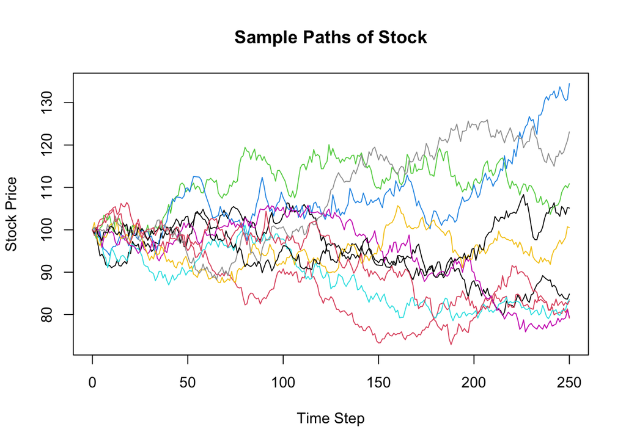

In the simulation above, it can be seen that the stock price path begins at 100 for each simulation since this is the stock price at time 0. The number of time steps chosen is 250 since there are roughly 250 trading days in 1 year. Each “day’s” price (i.e. time step 1, 2, 3 etc.) is determined by the price the day before and is modelled according to geometric Brownian motion. This creates one path. This process is repeated n times to create a wide variety of different outcomes. In this case, ten stock price paths are simulated, so the simulation has produced ten potential trajectories of the stock price, based on random fluctuations.

The Asian call option is then priced with the following steps:  
1. Simulate a stock path with geometric Brownian motion. 2. Sum up the prices on each of the m days and divide by m to obtain the average price of the asset over the entire term $\frac{1}{m} \sum_{i=1}^{m} s(t_i) = \bar{s}$.  
3. Subtract K from the average stock price over the entire term ($\text{average}-K$). Then the payoff of the Asian call option is max$\left(\bar{s}-K,0\right)$.  
4. Repeat steps 1-3 n times to obtain n different payoffs.  
5. Take the average of all n payoffs and discount it with $e^{-rt}$ where t is the expiration date.  
The more paths that are generated, the more accuracte the price will be. Shown below is an example of simulating 10000 stock paths.

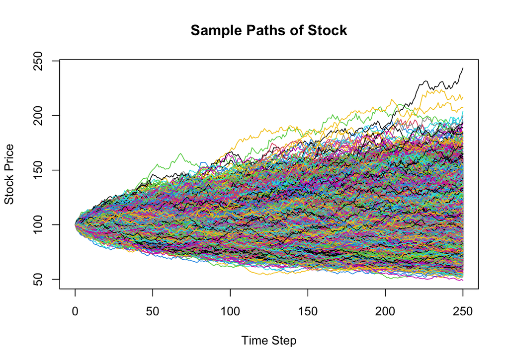

### 3.2.3 Variance of Asian Call Option Price

$$\theta = E[\text{payoff}] = E\left[\left( \bar{S} -K\right)^{+}_j\right]$$
$$\hat{\theta}_{DIR} = \frac{1}{n} \sum_{j=1}^{n} \left( \bar{s}
-K\right)^{+}_j$$
$\therefore$ the variance follows as
$$\begin{align*}
Var(\hat{\theta}_{DIR}) &= Var \left[ \frac{1}{n} \sum_{j=1}^{n}
\left( \bar{S} -K\right)^{+}_j \right]\\
&= \frac{1}{n^2} nVar\left[\left( \bar{S} -K\right)^{+}\right]\\
&=\frac{1}{n}Var\left[\left( \bar{S} -K\right)^{+}\right]
\end{align*}$$

$\therefore$ the variance of the price of the Asian call options follows as:
$$\begin{align*}
Var(\hat{C}) &= Var(e^{-rt}E[\text{payoff}]) \\
&=\frac{e^{-2rt} Var\left[\left( \bar{S} -K\right)^{+}\right]}{n}\\
&=\frac{e^{-2rt}Var(\text{payoff})}{n}
\end{align*}$$

# 4 Variance Reduction

Functions such as $E[g(X)]$ can be estimated using Monte Carlo integration. There are different methods that can be applied to reduce the variance of the sample mean estimator of $\theta = E[g(X)]$ (Rizzo 2019). Some of these methods include antithetic variables, control variables, importance sampling, Latin hypercube sampling and Quasi-monte carlo methods.

## 4.1 Antithetic Variables Method

### 4.1.1 Description

Suppose there are two identically distributed random variables $Y_1$ and $Y_2$. If $Y_1$ and $Y_2$ are independent, then:
$$Var(\frac{Y_1 + Y_2}{2}) = \frac{1}{4}(Var(Y_1) +
Var(Y_2))$$
otherwise, in general,
$$Var(\frac{Y_1 + Y_2}{2}) = \frac{1}{4}(Var(Y_1) +
Var(Y_2) + 2Cov(Y_1, Y_2))$$
From the above, it can be seen that if $Y_1$ and $Y_2$ are negatively correlated, then the variance of $\left(\frac{Y_1 + Y_2}{2} \right)$ is smaller than when $Y_1$ and $Y_2$ are independent (Rizzo 2019).

So, for the normal case, suppose that (Zhang 2009):
$$\theta = E[Y] = E[g(X)] \quad \text{where} \ X \sim N(0,1)$$
where the direct Monte Carlo estimate is:
$$\hat{\theta}_{DIR} = \frac{1}{n} \sum_{i=1}^{n} g(X_i) \quad
\text{where} \ X_i \overset{\text{i.i.d.}}{\sim} N(0,1)$$
and the antithetic variable estimate is:
$$\hat{\theta}_{AV} = \frac{1}{\frac{n}{2}} \sum_{i=1}^{\frac{n}{2}}
\frac{g(X_i)+g(-X_i)}{2} \quad \text{where} \ X_i
\overset{\text{i.i.d.}}{\sim} N(0,1)$$
where $X_i$ and $-X_i$ are the antithetic variates. The two antithetic variates are negatively correlated. Therefore, if the function $g$ is monotone increasing or decreasing, variance reduction can be achieved by using this method (Zhang 2009).

### 4.1.2 Implementation of Method to Price Asian Call Option

The following expected value needs to be estimated for Asian call options:
$$\theta = E[\text{payoff}] = E\left[\left(\bar{S} -K\right)^{+}\right]$$
1. Generate m random standard normal observations ($z_1, z_2, ... , z_m$).
2. Create another m standard normal observations that are negatively correlated with $z_1, z_2,...,z_m$ ($-z_1, -z_2, ... , -z_m$).
3. Generate a stock price path using $z_1, z_2, ... , z_m$ and another path using $-z_1, -z_2, ... , -z_m$. Remember the model underlying the stock price behaviour:
$$s_{t_i} = s_{t_{i-1}}e^{\left((r-\frac{\sigma^2}{2})\triangle t + \sigma
z_{t_{i}} \sqrt{\triangle t}\right)}$$
$$s_{t_i}^{'} =
s_{t_{i-1}}^{'}e^{\left((r-\frac{\sigma^2}{2})\triangle t + \sigma
(-z_{t_{i}}) \sqrt{\triangle t}\right)}$$
This will generate stock prices for m time steps.
4. Calculate the payoff from each path (there will be 2) by summing up the m stock prices and dividing by m and then subtracting K from this result:
$$\text{Payoff} = \left(\bar{S} - K \right)^{+} \quad \text{for one path}$$
and
$$\text{Payoff} =\left( \bar{S}' - K\right)^{+} \quad \text{for the
other path}$$
5. Now use Monte Carlo simulation to repeat this process $\frac{n}{2}$ times to obtain n simulated paths representing n different outcomes and calculating n different payoffs.
$$\hat{\theta} = \frac{1}{\frac{n}{2}} \sum_{j=1}^{\frac{n}{2}}
\frac{\left( \bar{s} -K\right)^{+}_j+\left( \bar{s}^{'}
-K\right)^{+}_j}{2}$$
6. The price of a Asian call option is calculated by discounting the payoff:
$$\hat{C}_{AV} = e^{-rt}\left[\frac{1}{\frac{n}{2}}
\sum_{j=1}^{\frac{n}{2}} \frac{\left( \bar{s} -K\right)^{+}_j+\left(
\bar{s}^{'} -K\right)^{+}_j}{2}\right]$$

### 4.1.3 Variance of Asian Call Option Price

$$\theta = E[\text{payoff}] = E\left[\left( \bar{S} -K\right)^{+}\right]$$
$$\hat{\theta}_{AV} = \frac{1}{\frac{n}{2}} \sum_{j=1}^{\frac{n}{2}}
\frac{\left( \bar{s} -K\right)^{+}_j+\left( \bar{s}^{'}
-K\right)^{+}_j}{2}$$
$\therefore$ the variance follows as (Rizzo 2019):
$$\begin{align*}
Var(\hat{\theta}_{AV}) &= Var \left[\frac{1}{\frac{n}{2}}
\sum_{j=1}^{\frac{n}{2}} \frac{\left( \bar{S} -K\right)^{+}_j+\left(
\bar{S}^{'} -K\right)^{+}_j}{2} \right] \\
&= \left(\frac{2}{n}\right)^2\frac{1}{4}Var
\left[\sum_{j=1}^{\frac{n}{2}}\left( \bar{S} -K\right)^{+}_j+\left(
\bar{S}^{'} -K\right)^{+}_j \right] \\
&=\left(\frac{1}{n^2}\right)\left(\frac{n}{2}\right)Var\left[\left(
\bar{S} -K\right)^{+}+\left( \bar{S}^{'} -K\right)^{+}\right]...
\text{since independent for different j}\\
&= \frac{1}{2n}\left[ Var\left(\left( \bar{S} -K\right)^{+} \right)
+ Var \left(\left( \bar{S}^{'} -K\right)^{+} \right) +
2Cov\left(\left( \bar{S} -K\right)^{+} ,\left( \bar{S}^{'}
-K\right)^{+}\right)\right]\\
&= \frac{1}{2n} \left[2Var \left( \left(\bar{S} -K\right)^{+}
\right) + 2Cov\left(\left( \bar{S} -K\right)^{+} ,\left(
\bar{S}^{'} -K\right)^{+}\right) \right]\\
&=\frac{1}{n}\left[ Var \left( \left(\bar{S} -K\right)^{+}
\right) + Cov\left(\left( \bar{S} -K\right)^{+} ,\left( \bar{S}^{'}
-K\right)^{+}\right) \right]\\
&= \frac{1}{n} \left[ Var(Y) + Cov(Y,Y') \right] ...
\text{since Y and Y' are identical}
\end{align*}$$
where Y is the payoff using standard normal random variables ($Z_1, Z_2, ... , Z_m$) and Y’ is the payoff using standard normal random variables that are negatively correlated to ($Z_1, Z_2, ... , Z_m$) i.e. ($-Z_1, -Z_2, ... , -Z_m$). Since the payoff function is monotone increasing, this method will reduce variance.

$\therefore$ the variance of the price of the Asian call option is:
$$\begin{align*}
Var(\hat{C}) &= Var(e^{-rt}E[\text{payoff}]) \\
&=e^{-2rt}Var(\hat{\theta}_{AV}) \\
&=\frac{e^{-2rt}}{n} \left[ Var(Y) + Cov(Y,Y') \right]
\end{align*}$$

where Y and Y’ are defined as above.

## 4.2 n-Simplex Antithetic Variate Method

### 4.2.1 The Simplex

A simplex is an object in geometry that generalises the idea of a triangle or tetrahedron to D-dimensions. In D dimensions, a simplex is determined by D+1 points. These are called the vertices of the simplex. A simplex in D dimensions is the convex hull of D+1 points $\mathbf{v}_1, \mathbf{v}_2,...,\mathbf{v}_{D+1}$. In 1D, this would be a straight line, 2D a triangle, 3D a tetrahedron and 4D a Pentatope. A regular D-simplex is a simplex where the euclidean distance between each of the D+1 points is equal and the angles between each face is the same. A regular D-simplex centred at the origin of a unit D-dimensional hypersphere is of interest as it has specific properties that will be shown later, which allow us to achieve variance reduction. From here on, this will be referred to as the regular D-simplex.The idea of the regular simplex is used to extend antithetic variables to multiple dimensions for random variables with symmetric probability distributions (Devriendt and Van Mieghem 2019). An example of a regular 2-simplex is shown below.

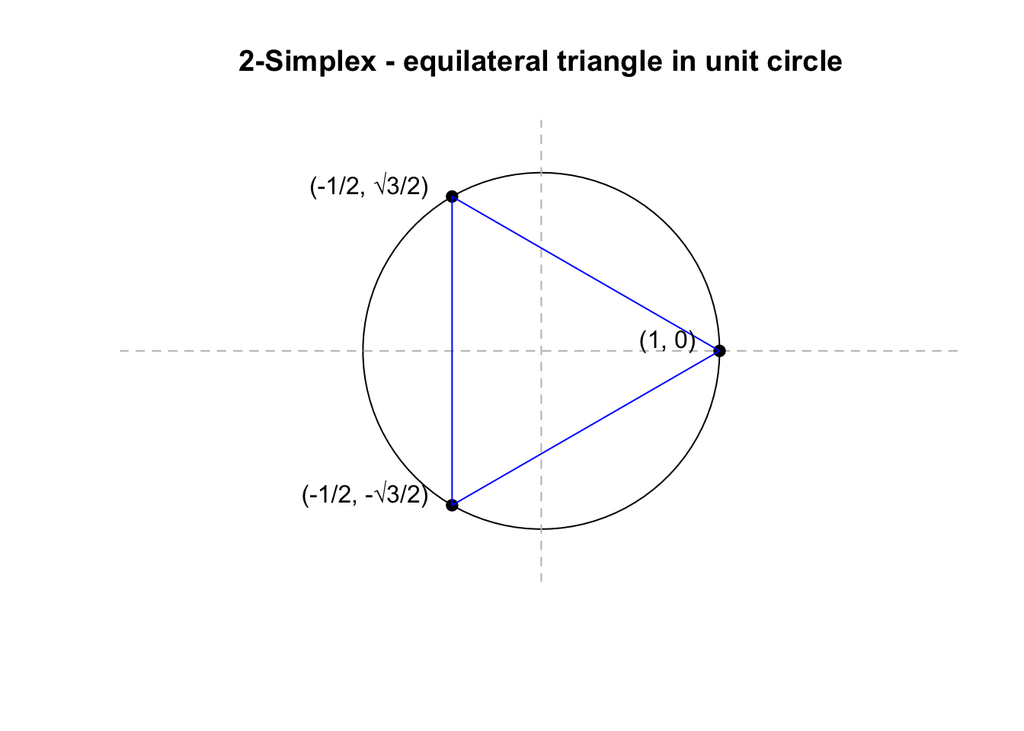

In two dimensions, as above, a simplex is determined by three points. These are points on a unit circle which correspond to the vertices of an inscribed equilateral triangle. Any three points can be chosen on the unit circle as long as these points form an equilateral triangle. One such example is: $\left(1,0\right)$, $\left(-\frac{1}{2},\frac{\sqrt{3}}{2}\right)$ and $\left(-\frac{1}{2}, -\frac{\sqrt{3}}{2}\right)$ (Park and Choe 2016). Confirm these points are correct by calculating the Euclidean distance between each point and ensuring it is the same for each pair of points.

### 4.2.2 n-Simplex Method

Let $\mathbf{v}_1, \mathbf{v}_2,...,\mathbf{v}_{D+1}$ be the vertices of a regular D-simplex. The vertices have the following properties:
$$\lVert \mathbf{v}_i \rVert ^2 = 1 \quad \forall i=1,2, ..., D+1 \quad
(\text{by definition})$$
and

$\mathbf{v}_i ' \mathbf{v}_j = -\frac{1}{D} \quad \text{for} \ i\neq j$ (see Parks and Wills (2002))

Let $\mathbf{Z}={Z}_1, {Z}_2,...,{Z}_D$ be a vector of D standard normal random variables, then:
$$\mathbf{v}_i'\mathbf{Z} \sim N(0,1)$$
and
$$\text{Cov}(\mathbf{v}_i'\mathbf{Z}, \mathbf{v}_j'\mathbf{Z})=
-\frac{1}{D}$$
The D-simplex average of $g$ is:
$$S(\mathbf{Z}) = \frac{1}{D+1}
\sum_{i=1}^{D+1}g(\mathbf{v}_i'\mathbf{Z})$$
$\therefore$ the Monte Carlo estimator of $E[S(\mathbf{Z})]$ is:
$$\frac{1}{\frac{n}{D+1}}\sum_{j=1}^{\frac{n}{D+1}} S(\mathbf{Z}_j)$$
It is now shown that using this estimator will reduce variance from the direct method:
$$\begin{align*}
Var(S(\mathbf{Z})) &= Var\left(\frac{1}{D+1}
\sum_{i=1}^{D+1}g(\mathbf{v}_i'\mathbf{Z})\right)\\
&= \frac{1}{{(D+1)}^2}
Var\left(\sum_{i=1}^{D+1}g(\mathbf{v}_i'\mathbf{Z}) \right)\\
&=\frac{1}{{(D+1)}^2}\left[
\sum_{i=1}^{D+1}Var\left(g(\mathbf{v}_i'\mathbf{Z})\right) + \sum_{i
\neq
j}^{D+1}\text{Cov}\left(g(\mathbf{v}_i'\mathbf{Z}),g(\mathbf{v}_j'\mathbf{Z}\right) \right]\\
&=\frac{1}{{(D+1)}^2} \left[(D+1)Var(g(Z)) + D(D+1)
\text{Cov}\left(g(\mathbf{v}_1'\mathbf{Z}),
g(\mathbf{v}_2'\mathbf{Z})\right) \right] \quad
\text{since} \ \mathbf{v}_i'\mathbf{Z} \sim \text{N}(0,1) \\
&= \frac{1}{(D+1)} \left[Var(g(Z)) +
n\text{Cov}\left(g(\mathbf{v}_1'\mathbf{Z}),g(\mathbf{v}_2'\mathbf{Z})\right) \right]
\\
\end{align*}$$
It is shown in theory that two monotone increasing functions where the variables in each function are negatively correlated has a covariance of less than or equal to zero. Hence,
$$\begin{align*}
\text{Cov}\left(g(\mathbf{v}_1'\mathbf{Z}),
g(\mathbf{v}_2'\mathbf{Z})\right) \leq 0 \\
\therefore Var(S(\mathbf{Z})) \leq \frac{1}{D+1} Var(g(Z))
\end{align*}$$
Hence, a variance reduction is achieved with a higher dimesnions resulting in a higher reduction. It follows that the case for which the dimension is one is simply the antithetic variables method.

### 4.2.3 Implementation of Method to Price Asian Call Option

Consider the implementation of the n-simplex method to price Asian call options. Let D be the number of dimensions, therefore D+1 points are used to determine the simplex:
Remember, the following expected value needs to be estimated for Asian call options:
$$\theta = E[\text{payoff}] = E\left[\left(\bar{S} -K\right)^{+}\right]$$
1. Compute D+1 vertices of the regular D-simplex: $\mathbf{v}_1, \mathbf{v}_2,...,\mathbf{v}_{D+1}$. 2. Generate D vectors, $\mathbf{z} = \mathbf{z}_1,\mathbf{z}_2,...,\mathbf{z}_D$, each containing m observations of standard normal random variables.
$$\mathbf{z}^{(1)}=z_1^{(1)}, z_2^{(1)}, ...,
z_m^{(1)}$$
$$\mathbf{z}^{(2)}=z_1^{(2)},
z_2^{(2)}, ..., z_m^{(2)}$$

.  
.  
.

$$\mathbf{z}^{(D)}=z_1^{(D)}, z_2^{(D)}, ..., z_m^{(D)}$$
3. Generate D+1 stock price paths. Remember the model underlying the stock price behaviour:
$$s_{t_j}^{(1)} = s_{t_{j-1}}e^{\left((r-\frac{\sigma^2}{2})\triangle t +
\sigma (x_{ij}) \sqrt{\triangle t}\right)}$$
$$s_{t_j}^{(2)} = s_{t_{j-1}}e^{\left((r-\frac{\sigma^2}{2})\triangle t +
\sigma (x_{ij}) \sqrt{\triangle t}\right)}$$

.  
.  
.

$$s_{t_j}^{(D+1)} = s_{t_{j-1}}e^{\left((r-\frac{\sigma^2}{2})\triangle t
+ \sigma (x_{ij}) \sqrt{\triangle t}\right)}$$
for $j = 1,...,m$ and $i = 1,2,...,D+1$,
where $x_{ij}=[ \mathbf{z}_j^{(1)},\mathbf{z}_j^{(2)},...,\mathbf{z}_j^{(D)} ]' \mathbf{v}_i$
This generates the stock price path for m time steps.
4. Calculate the payoff from each path (there are D+1 paths) by summing up the m stock prices and dividing by m and then subtracting K from this result:
$$\text{Payoff} = (\bar{S} - K)^+ \ \text{for D+1 paths}$$
5. Then calculate the average of the the D+1 payoffs:
$$S(\mathbf{Z}) = \frac{1}{D+1} \sum_{i=1}^{D+1}\text{payoff}_i$$
6. Repeat steps 2 to 5 $\frac{n}{D+1}$ times.
7. Calculate the mean of the $\frac{n}{D+1}$ average payoffs.
$$\frac{1}{\frac{n}{D+1}}\sum_{j=1}^{\frac{n}{D+1}} S(\mathbf{Z}_j)$$
8. Discount this using the risk-free rate to obtain the price of the Asian call option.
$$\frac{e^{-rt}}{\frac{n}{D+1}}\sum_{j=1}^{\frac{n}{D+1}} S(\mathbf{Z}_j)$$

# 5 Analyis

## 5.1 Results

The methods were compared using the following constants:

| S | r | $\sigma$ | t | m |
| --- | --- | --- | --- | --- |
| 100 | 5% | 20% | 1 | 250 |

where:  
- S is the initial stock price.  
- r is the risk-free rate of interest.  
- $\sigma$ is the volatility of the underlying asset.  
- t is the expiration date.  
- m is the number of of time steps.

The price and standard error for each method was obtained and compared. All methods were implemented using the algorithms that have been described. The n-simplex method was done in 2,3 and 4 dimensions. For the 2-Simplex, the points $\left(1,0\right)$, $\left(-\frac{1}{2},\frac{\sqrt{3}}{2}\right)$ and $\left(-\frac{1}{2}, -\frac{\sqrt{3}}{2}\right)$ were used. For the 3-Simplex, the points $\left(1,0,0\right)$, $\left(-\frac{1}{3}, \frac{\sqrt{5}}{3}, \frac{\sqrt{3}}{3}\right)$, $\left(-\frac{1}{3}, \frac{-3-\sqrt{5}}{6},\frac{\sqrt{15}- \sqrt{3}}{6}\right)$ and $\left(-\frac{1}{3}, \frac{3-\sqrt{5}}{6},\frac{-\sqrt{15}- \sqrt{3}}{6}\right)$. For the 4-Simplex, the points $\left(1,0,0,0\right)$, $\left(-\frac{1}{4}, \frac{\sqrt{5}}{4}, \frac{\sqrt{5}}{4}, \frac{\sqrt{5}}{4}\right)$, $\left(-\frac{1}{4}, \frac{\sqrt{5}}{4}, \frac{\sqrt{5}}{4}, -\frac{\sqrt{5}}{4}\right)$, $\left(-\frac{1}{4}, -\frac{\sqrt{5}}{4}, \frac{\sqrt{5}}{4}, -\frac{\sqrt{5}}{4}\right)$, $\left(-\frac{1}{4}, -\frac{\sqrt{5}}{4}, -\frac{\sqrt{5}}{4}, \frac{\sqrt{5}}{4}\right)$ were used.

The results are shown in the following table:

**Table 1: Price and Standard Error from the Respective Methods**

| K | n | Direct Price | Direct Standard Error | Antithetic Price | Antithetic Standard Error | 2-Simplex Price | 2-Simplex Standard Error | 3-Simplex Price | 3-Simplex Standard Error | 4-Simplex Price | 4-Simplex Standard Error |
| --- | --- | --- | --- | --- | --- | --- | --- | --- | --- | --- | --- |
| **90** | 1000 | 12.4460032 | 0.3311263 | 12.5910275 | 0.0779235 | 12.7125288 | 0.0616781 | 12.6531519 | 0.0485739 | 12.6325109 | 0.0407488 |
|  | 10000 | 12.2502963 | 0.1030852 | 12.6535324 | 0.0262378 | 12.6595636 | 0.0191964 | 12.5738923 | 0.0149061 | 12.641749 | 0.0134756 |
|  | 100000 | 12.5760381 | 0.0328587 | 12.5952972 | 0.0080794 | 12.5988367 | 0.0058909 | 12.6113355 | 0.0049189 | 12.622577 | 0.004298 |
| **100** | 1000 | 5.6471704 | 0.2479236 | 5.7497325 | 0.1188981 | 5.5403375 | 0.0884598 | 6.019846 | 0.0736781 | 5.7657782 | 0.0655925 |
|  | 10000 | 5.7125285 | 0.0791181 | 5.841334 | 0.0395917 | 5.7921468 | 0.0279956 | 5.771464 | 0.022354 | 5.8010235 | 0.0196518 |
|  | 100000 | 5.7945981 | 0.0252818 | 5.7789596 | 0.0123892 | 5.7535033 | 0.008728 | 5.799311 | 0.007146 | 5.7766056 | 0.0061861 |
| **110** | 1000 | 1.7625177 | 0.1466419 | 2.2789927 | 0.1101315 | 2.1089458 | 0.0712889 | 1.8044669 | 0.061542 | 1.8673282 | 0.053071 |
|  | 10000 | 2.0247357 | 0.0491702 | 1.992935 | 0.031468 | 1.9151001 | 0.0232067 | 2.0352066 | 0.019724 | 1.9766151 | 0.0170209 |
|  | 100000 | 1.9838713 | 0.0155051 | 2.0082807 | 0.0100448 | 2.0042841 | 0.0075508 | 2.0088451 | 0.00623 | 2.0206087 | 0.0054785 |

The variance reduction achieved from each method is summarised as follows:

**Table 2: Variance Reduction Compared to the Direct Method**

|  |  | **Antithetic** | **2-Simplex** | **3-Simplex** | **4-Simplex** |
| --- | --- | --- | --- | --- | --- |
| **K** | **n** | **Variance Reduction** | **Variance Reduction** | **Variance Reduction** | **Variance Reduction** |
| **90** | 1000 | 0.9446204 | 0.9653044 | 0.9784812 | 0.984856 |
|  | 10000 | 0.9352167 | 0.9653224 | 0.9790909 | 0.9829114 |
|  | 100000 | 0.9395421 | 0.9678594 | 0.9775902 | 0.9828909 |
| **100** | 1000 | 0.7700071 | 0.8726919 | 0.9116837 | 0.930004 |
|  | 10000 | 0.7495876 | 0.874793 | 0.9201717 | 0.9383048 |
|  | 100000 | 0.7598565 | 0.8808187 | 0.9201076 | 0.94013 |
| **110** | 1000 | 0.4359631 | 0.7636652 | 0.8238724 | 0.869022 |
|  | 10000 | 0.5904233 | 0.7772475 | 0.839088 | 0.880171 |
|  | 100000 | 0.5803091 | 0.7628422 | 0.8385525 | 0.8751548 |

## 5.2 Analysis of results

The output from the tables above show that significant variance reduction was achieved for all the variance reduction methods. The standard error decreases as the number of repetitions increase, as expected.The n-simplex method also outperforms the antithetic variable method. It is seen that as the number of dimensions for the n-simplex increases, the variance reduction increases. This agrees with the theory of the variance reduction shown in 4.2.2 . It is interesting to note that the variance reduction for all methods decreases as the strike price increases. This could be due to the fact that more of the paths with out-the-money call options will provide a payoff of zero compared to in-the-money call options. The covariance between any random variable and zero is always zero, hence a zero payoff does not provide negative covariance. This means more payoffs of zero results in lower variance reduction.

# 6 Conclusion

This project illustrates the usefulness of using Monte Carlo simulation to price Asian options. Furthermore, we see how variance reduction methods can improve the accuracy of the prices. The n-simplex is shown to be a useful variance reduction technique that outperforms antithetic variables in terms of variance reduction. However, it is slightly more complicated and harder to implement.

# References

Devriendt, Karel, and Piet Van Mieghem. 2019. “The Simplex Geometry of Graphs.” *Journal of Complex Networks* 7 (4): 469–90.

Hull, John C. 2017. *Options, Futures, and Other Derivatives*. Global edition. Pearson Education.

Nielsen, Lars B. 2001. “Pricing Asian Options.” *Aarhus Universitet, Institut for Matematiske Fag, Afdeling for Nationaløkonomi*.

Park, Jong Jun, and Geon Ho Choe. 2016. “A New Variance Reduction Method for Option Pricing Based on Sampling the Vertices of a Simplex.” *Quantitative Finance* 16 (8): 1165–73.

Parks, Harold R, and Dean C Wills. 2002. “An Elementary Calculation of the Dihedral Angle of the Regular n-Simplex.” *The American Mathematical Monthly* 109 (8): 756–58.

Rizzo, Maria L. 2019. *Statistical Computing with r*. Chapman; Hall/CRC.

Zhang, Hongbin. 2009. *Pricing Asian Options Using Monte Carlo Methods*.